# Chapter 2 Exercises

```r
library(sf)
library(spData)
library(sp)
library(raster)
```

## Question 1

Use summary() on the geometry column of the world data object. What does the output tell us about: -Its geometry type? -The number of countries? -Its coordinate reference system (CRS)?

```r
summary(world["geom"])
```

```
            geom
 MULTIPOLYGON :177
 epsg:4326    :  0
 +proj=long...:  0
```

Geometry Type: MULTIPOLYGON Number of Countries: 177 (can be seen from num of polygons) CRS: WGS84 (EPSG 4326)

## Question 2

-What does the cex argument do (see ?plot)? -Why was cex set to the sqrt(world$pop) / 10000? -Bonus: experiment with different ways to visualize the global population.

This code was taken from the book but copied into this file for convenience

```r
plot(world["continent"], reset = FALSE)
cex = sqrt(world$pop) / 10000
world_cents = st_centroid(world, of_largest = TRUE)
```

```
st_centroid assumes attributes are constant over geometries of xst_centroid does not give correct centroids for longitude/latitude data
```

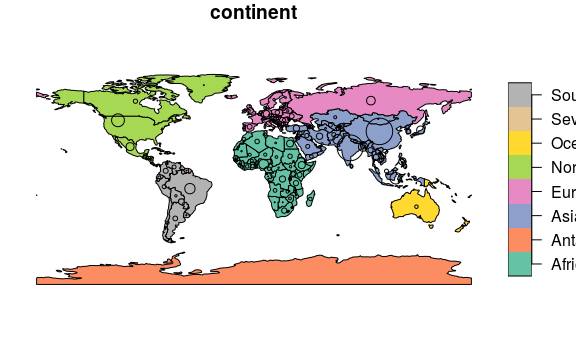

```r
plot(st_geometry(world_cents), add = TRUE, cex = cex)
```

## Question 3

```r
# take the row associated with nigeria
nigeria = world[world$name_long == "Nigeria", ]
# plot the shape (geometry), set the bounding box, color, and line width
plot(st_geometry(nigeria), expandBB = c(1, 1, 0.5, 1), col = "pink", lwd = 4)
#get all the countries in afria
africa = world[world$continent == "Africa",]
#add all the other countries to the plot
plot(africa[0], add = TRUE)
```

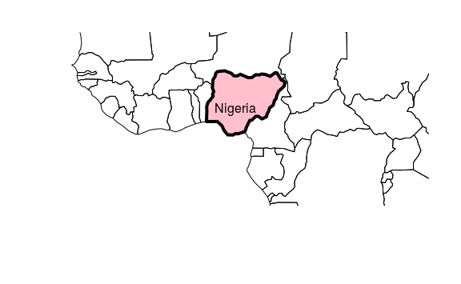

```r
text(x = 7, y = 8, labels = "Nigeria")
```

## Question 4

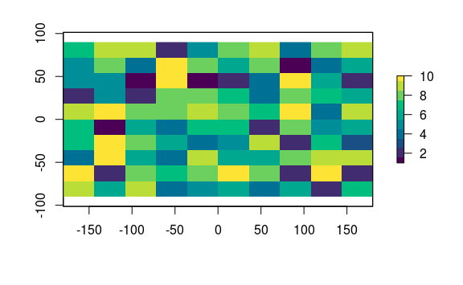

```r
my_raster = raster(nrows = 10, ncols = 10)
values = vector(mode = "numeric", length = 100)
 for (i in 1:100){
    values[i] = sample(1:10, 1);
 }


# I thought there was a better way to generate random numbers 100 times than a loop so I tried this but it didn't seem to work so I went back to the loop
# sapply(values, sample, 1:10, 1)

# take the values I generated and set raster label values at them
my_raster = setValues(my_raster, values)

# This line was from when I was trying to make sure my numbers were generating properly
#getValues(my_raster)

# plot raster by specifying my taster, which colors i want, transparency,
 plot(my_raster, col = hcl.colors(10, palette = "viridis", alpha = NULL), maxpixels = 100)
```

## Question 5

```r
file = raster(system.file("raster/nlcd2011.tif", package = "spDataLarge"))
file
```

```
class      : RasterLayer
dimensions : 1359, 1073, 1458207  (nrow, ncol, ncell)
resolution : 31.5303, 31.52466  (x, y)
extent     : 301903.3, 335735.4, 4111244, 4154086  (xmin, xmax, ymin, ymax)
crs        : +proj=utm +zone=12 +ellps=GRS80 +towgs84=0,0,0,0,0,0,0 +units=m +no_defs
source     : /home/rstudio-user/R/x86_64-pc-linux-gnu-library/3.6/spDataLarge/raster/nlcd2011.tif
names      : nlcd2011
values     : 11, 95  (min, max)
```

You can get the class, dimensions, resolution, extent, information such as projection, szone, units, the source, names, and the min max values